# Mini-Project3_YangJ_XieX

Jackie Yang, Xinyu Xie

2025-04-28

## Front Matter

```r
library(readxl)
library(dplyr)
```

```r
library(ggplot2)
library(tidyr)
library(MASS)
library(glmnet)
library(rpart)
library(rattle)
CODGames2_mp <- read_excel("C:/ESSENTIALS/School OS/Junior Spring 2025/STAT 380/Datasets/CODGames2_mp.xlsx")
```

## Task 1 - Remove Partial

```r
CODGames2_mp <- CODGames2_mp %>%
  filter(FullPartial != "Partial")
CODGames2_mp
```

```
## # A tibble: 191 × 27
##    Map1              Map2  Choice MapVote Date                FullPartial Result
##    <chr>             <chr> <chr>  <chr>   <dttm>              <chr>       <chr>
##  1 Moscow            Miam… Miami… 5 to 0  2022-06-06 00:00:00 Full        100-97
##  2 Moscow            WMD   Moscow 2 to 0  2022-06-06 00:00:00 Full        76-89
##  3 <NA>              <NA>  Yaman… <NA>    2022-06-06 00:00:00 Full        100-92
##  4 Drive-In          Jung… Drive… 2 to 0  2022-06-06 00:00:00 Full        80-100
##  5 Collateral Strike Hija… Colla… 3 to 3  2022-06-06 00:00:00 Full        71-100
##  6 Crossroads Strike Raid  Raid   4 to 3  2022-06-06 00:00:00 Full        85-100
##  7 <NA>              <NA>  WMD    <NA>    2022-06-06 00:00:00 Full        86-100
##  8 The Pines         Stan… Stand… 5 to 1  2022-06-06 00:00:00 Full        100-70
##  9 Echelon           Depr… Depro… 1 to 0  2022-06-12 00:00:00 Full        46-65
## 10 Nuketown '84      Hija… Nuket… 1 to 1  2022-06-12 00:00:00 Full        47-65
## # ℹ 181 more rows
## # ℹ 20 more variables: Eliminations <dbl>, Deaths <dbl>, Score <dbl>,
## #   Damage <dbl>, TotalXP <dbl>, PrimaryWeapon <chr>, XPType <chr>,
## #   DidPlayerVote <chr>, GameType <chr>, Confirms <dbl>, Denies <dbl>,
## #   Objectives <dbl>, ObjectiveKills <dbl>, Captures <dbl>, Diffuses <lgl>,
## #   Plants <lgl>, Detonates <lgl>, Deposits <lgl>, Time_Sec <dbl>,
## #   Time_Min <dbl>
```

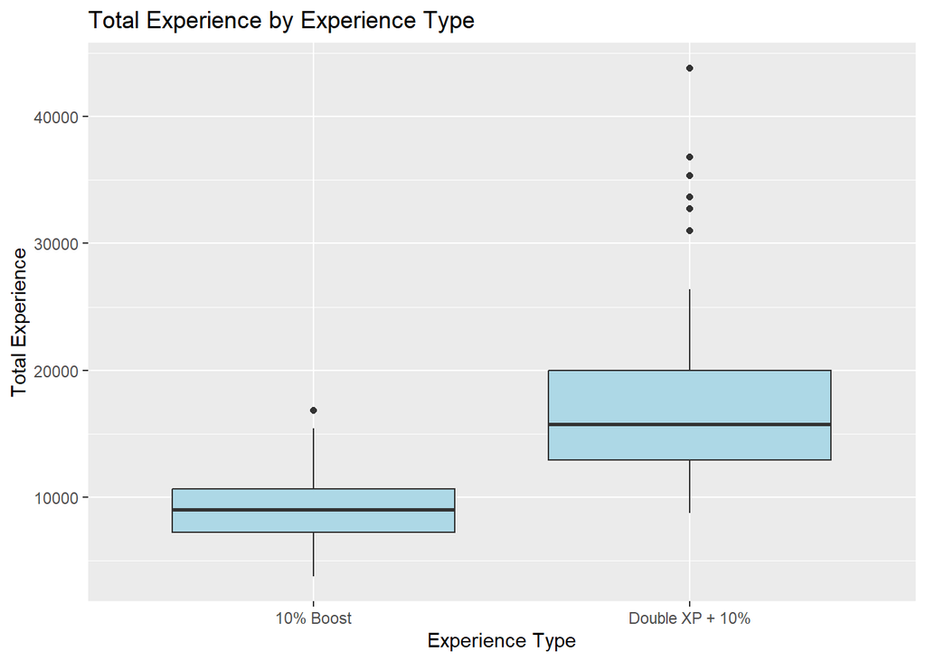

```r
ggplot(CODGames2_mp, aes(x = XPType, y = TotalXP)) +
  geom_boxplot(fill = "lightblue") +
  labs(x = "Experience Type", y = "Total Experience", title = "Total Experience by Experience Type")
```

```r
CODGames2_mp %>%
  group_by(XPType) %>%
  summarize(
    Mean = mean(TotalXP, na.rm = TRUE),
    Median = median(TotalXP, na.rm = TRUE),
    SD = sd(TotalXP, na.rm = TRUE),
    Min = min(TotalXP, na.rm = TRUE),
    Max = max(TotalXP, na.rm = TRUE),
    Count = n()
  )
```

```
## # A tibble: 2 × 7
##   XPType            Mean Median    SD   Min   Max Count
##   <chr>            <dbl>  <dbl> <dbl> <dbl> <dbl> <int>
## 1 10% Boost        9094.   9039 2606.  3795 16831   111
## 2 Double XP + 10% 17242.  15738 6649.  8772 43816    80
```

Based on the summary statistics, the games where the player had Double XP + 10% as the experience type generally had more total experience than when the player had only the 10% Boost. Also, looking at the boxplots, the distribution of the experience type DOuble XP + 10% shows a higher spread than the experience type 10% Boost. Additionally, there seems to be more outliers.

## Task 2 Building Model

```r
CODGames2_mp_HC_TDM <- CODGames2_mp %>%
  filter(GameType == "HC - TDM")

CODGames2_mp_HC_TDM <- CODGames2_mp_HC_TDM %>%
  separate(Result, into = c("PlayerScore", "OpponentScore"), sep = "-", convert = TRUE) %>%
  mutate(
    Outcome = case_when(
      PlayerScore > OpponentScore ~ "Win",
      PlayerScore < OpponentScore ~ "Loss",
      PlayerScore == OpponentScore ~ "Draw"
    ),
    Win = ifelse(PlayerScore > OpponentScore, 1, 0)
  )
CODGames2_mp_HC_TDM
```

```
## # A tibble: 178 × 30
##    Map1         Map2  Choice MapVote Date                FullPartial PlayerScore
##    <chr>        <chr> <chr>  <chr>   <dttm>              <chr>             <int>
##  1 Moscow       Miam… Miami… 5 to 0  2022-06-06 00:00:00 Full                100
##  2 Moscow       WMD   Moscow 2 to 0  2022-06-06 00:00:00 Full                 76
##  3 <NA>         <NA>  Yaman… <NA>    2022-06-06 00:00:00 Full                100
##  4 Drive-In     Jung… Drive… 2 to 0  2022-06-06 00:00:00 Full                 80
##  5 Collateral … Hija… Colla… 3 to 3  2022-06-06 00:00:00 Full                 71
##  6 Crossroads … Raid  Raid   4 to 3  2022-06-06 00:00:00 Full                 85
##  7 <NA>         <NA>  WMD    <NA>    2022-06-06 00:00:00 Full                 86
##  8 The Pines    Stan… Stand… 5 to 1  2022-06-06 00:00:00 Full                100
##  9 Jungle       Hija… Jungle 1 to 0  2022-06-13 00:00:00 Full                100
## 10 Rush         Cart… Rush   1 to 1  2022-06-13 00:00:00 Full                100
## # ℹ 168 more rows
## # ℹ 23 more variables: OpponentScore <int>, Eliminations <dbl>, Deaths <dbl>,
## #   Score <dbl>, Damage <dbl>, TotalXP <dbl>, PrimaryWeapon <chr>,
## #   XPType <chr>, DidPlayerVote <chr>, GameType <chr>, Confirms <dbl>,
## #   Denies <dbl>, Objectives <dbl>, ObjectiveKills <dbl>, Captures <dbl>,
## #   Diffuses <lgl>, Plants <lgl>, Detonates <lgl>, Deposits <lgl>,
## #   Time_Sec <dbl>, Time_Min <dbl>, Outcome <chr>, Win <dbl>
```

```r
full_model <- lm(Score ~ TotalXP + Eliminations + Deaths + Damage + XPType + Win, data = CODGames2_mp_HC_TDM)

summary(full_model)
```

```
##
## Call:
## lm(formula = Score ~ TotalXP + Eliminations + Deaths + Damage +
##     XPType + Win, data = CODGames2_mp_HC_TDM)
##
## Residuals:
##      Min       1Q   Median       3Q      Max
## -1972.71  -437.32    -7.79   319.13  2909.58
##
## Coefficients:
##                         Estimate Std. Error t value Pr(>|t|)
## (Intercept)            946.58489  325.12519   2.911 0.004077 **
## TotalXP                  0.06142    0.01344   4.569 9.35e-06 ***
## Eliminations           153.77046   65.34616   2.353 0.019751 *
## Deaths                 -73.64183   15.18456  -4.850 2.76e-06 ***
## Damage                   1.13774    2.32198   0.490 0.624771
## XPTypeDouble XP + 10% -380.58562  149.87276  -2.539 0.011996 *
## Win                   -458.64539  116.62779  -3.933 0.000122 ***
## ---
## Signif. codes:  0 '***' 0.001 '**' 0.01 '*' 0.05 '.' 0.1 ' ' 1
##
## Residual standard error: 706.9 on 171 degrees of freedom
## Multiple R-squared:  0.7701, Adjusted R-squared:  0.762
## F-statistic: 95.45 on 6 and 171 DF,  p-value: < 2.2e-16
```

NOTE: The variable Damage seems to be insignificant as it has a large p-value (> 0.05)

## Task 2a. LASSO Regresison and Other Feature Selection Method

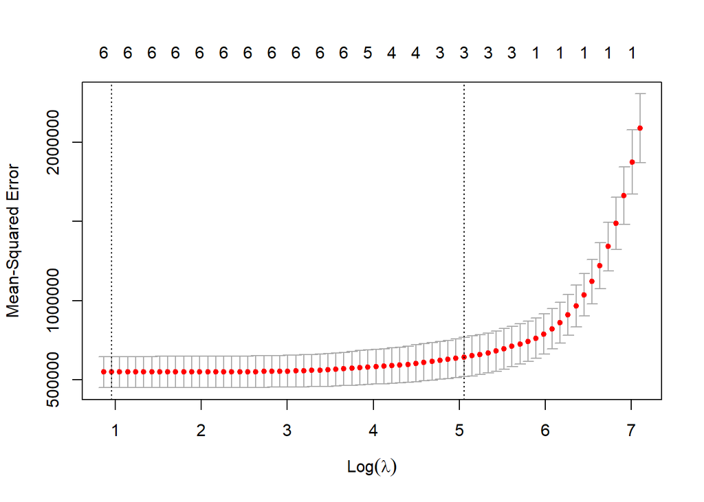

```r
Xmat <- model.matrix(Score ~ TotalXP + Eliminations + Deaths + Damage + XPType + Win, data = CODGames2_mp_HC_TDM)[ , -1]
Ymat <- CODGames2_mp_HC_TDM$Score

lasso_model <- glmnet(Xmat, Ymat, alpha = 1)

set.seed(123)
lassoCV <- cv.glmnet(Xmat, Ymat, alpha = 1)
set.seed(NULL)

plot(lassoCV)
```

```r
best_lambda <- lassoCV$lambda.min
best_lambda
```

```
## [1] 2.611974
```

```r
coef(lassoCV, s = "lambda.min")
```

```
## 7 x 1 sparse Matrix of class "dgCMatrix"
##                                  s1
## (Intercept)            937.15693473
## TotalXP                  0.05984054
## Eliminations           159.12937918
## Deaths                 -72.77820466
## Damage                   0.94772672
## XPTypeDouble XP + 10% -361.57550500
## Win                   -447.19199686
```

LASSO regression selected a value of $\lambda = 2.611974$ which produced the lowest MSE value. This produced the equation: `Score` = 937.15693473 + 0.05984054`TotalXP` + 159.12937918`Eliminations` - 72.77820466`Deaths` + 0.94772672`Damage` - 361.57550500`XPTypeDouble XP + 10%` - 447.19199686`Win`.

```r
stepwise_model <- stepAIC(full_model, direction = "both")
```

```
## Start:  AIC=2342.53
## Score ~ TotalXP + Eliminations + Deaths + Damage + XPType + Win
##
##                Df Sum of Sq      RSS    AIC
## - Damage        1    119968 85565679 2340.8
## <none>                      85445711 2342.5
## - Eliminations  1   2766940 88212652 2346.2
## - XPType        1   3222207 88667919 2347.1
## - Win           1   7727591 93173302 2355.9
## - TotalXP       1  10431500 95877211 2361.0
## - Deaths        1  11752728 97198439 2363.5
##
## Step:  AIC=2340.78
## Score ~ TotalXP + Eliminations + Deaths + XPType + Win
##
##                Df Sum of Sq       RSS    AIC
## <none>                       85565679 2340.8
## + Damage        1    119968  85445711 2342.5
## - XPType        1   3103670  88669349 2345.1
## - Win           1   7627935  93193614 2354.0
## - TotalXP       1  10318883  95884562 2359.0
## - Deaths        1  11660493  97226172 2361.5
## - Eliminations  1 118217717 203783396 2493.2
```

```r
summary(stepwise_model)
```

```
##
## Call:
## lm(formula = Score ~ TotalXP + Eliminations + Deaths + XPType +
##     Win, data = CODGames2_mp_HC_TDM)
##
## Residuals:
##      Min       1Q   Median       3Q      Max
## -2000.77  -444.28   -35.43   327.75  2912.93
##
## Coefficients:
##                         Estimate Std. Error t value Pr(>|t|)
## (Intercept)            944.05302  324.36521   2.910  0.00409 **
## TotalXP                  0.06054    0.01329   4.554 9.91e-06 ***
## Eliminations           185.24081   12.01658  15.415  < 2e-16 ***
## Deaths                 -73.25104   15.13007  -4.841 2.86e-06 ***
## XPTypeDouble XP + 10% -367.94000  147.30748  -2.498  0.01344 *
## Win                   -454.44701  116.05540  -3.916  0.00013 ***
## ---
## Signif. codes:  0 '***' 0.001 '**' 0.01 '*' 0.05 '.' 0.1 ' ' 1
##
## Residual standard error: 705.3 on 172 degrees of freedom
## Multiple R-squared:  0.7697, Adjusted R-squared:  0.763
## F-statistic:   115 on 5 and 172 DF,  p-value: < 2.2e-16
```

Using step-wise selection, it produced the equation: `Score` = 944.05302 + 0.06054`TotalXP` + 185.24081`Eliminations` - 73.25104`Deaths` - 367.94000`XPTypeDouble XP + 10%` - 454.44701`Win`. We can see that the step-wise model removed the variable `Damage` while the LASSO regression did not. The coefficients of the variables for both models have the same sign and seem to be fairly close in value.

## Task 2b. Regression Tree

```r
RegTree <- rpart(Score ~ TotalXP + Eliminations + Deaths + Damage + XPType + Win,
                 method = "anova",
                 data = CODGames2_mp_HC_TDM,
                 minbucket = 3,
                 control = rpart.control(minbucket = 15)
)

summary(RegTree)
```

```
## Call:
## rpart(formula = Score ~ TotalXP + Eliminations + Deaths + Damage +
##     XPType + Win, data = CODGames2_mp_HC_TDM, method = "anova",
##     control = rpart.control(minbucket = 15), minbucket = 3)
##   n= 178
##
##           CP nsplit rel error    xerror       xstd
## 1 0.48008258      0 1.0000000 1.0048825 0.12133716
## 2 0.11082026      1 0.5199174 0.5815118 0.08462482
## 3 0.07655985      2 0.4090972 0.4730643 0.07428836
## 4 0.01986246      3 0.3325373 0.4174583 0.07416355
## 5 0.01000000      4 0.3126748 0.4282799 0.07841897
##
## Variable importance
##       Damage Eliminations      TotalXP       Deaths          Win       XPType
##           40           38           10            6            4            2
##
## Node number 1: 178 observations,    complexity param=0.4800826
##   mean=3104.949, MSE=2087648
##   left son=2 (97 obs) right son=3 (81 obs)
##   Primary splits:
##       Damage       < 442.5   to the left,  improve=0.48008260, (0 missing)
##       Eliminations < 15.5    to the left,  improve=0.47223540, (0 missing)
##       TotalXP      < 19366   to the left,  improve=0.20969430, (0 missing)
##       Deaths       < 15.5    to the right, improve=0.13865960, (0 missing)
##       Win          < 0.5     to the left,  improve=0.03019796, (0 missing)
##   Surrogate splits:
##       Eliminations < 15.5    to the left,  agree=0.966, adj=0.926, (0 split)
##       TotalXP      < 11683.5 to the left,  agree=0.691, adj=0.321, (0 split)
##       Deaths       < 15.5    to the right, agree=0.635, adj=0.198, (0 split)
##       Win          < 0.5     to the left,  agree=0.612, adj=0.148, (0 split)
##       XPType       splits as  LR,          agree=0.573, adj=0.062, (0 split)
##
## Node number 2: 97 observations,    complexity param=0.07655985
##   mean=2190.113, MSE=624482.9
##   left son=4 (40 obs) right son=5 (57 obs)
##   Primary splits:
##       Damage       < 327.5   to the left,  improve=0.469662700, (0 missing)
##       Eliminations < 10.5    to the left,  improve=0.464516500, (0 missing)
##       TotalXP      < 6553.5  to the left,  improve=0.107755400, (0 missing)
```

[output cut: 31 more lines]

```
##       Deaths       < 15.5    to the right, improve=0.06377538, (0 missing)
##       TotalXP      < 11417.5 to the left,  improve=0.05020171, (0 missing)
##       Win          < 0.5     to the right, improve=0.03844909, (0 missing)
##   Surrogate splits:
##       Eliminations < 19.5    to the left,  agree=0.952, adj=0.85, (0 split)
##       Deaths       < 18.5    to the left,  agree=0.762, adj=0.25, (0 split)
##
## Node number 7: 18 observations
##   mean=5534.444, MSE=811513.6
##
## Node number 12: 43 observations
##   mean=3585.93, MSE=1103844
##
## Node number 13: 20 observations
##   mean=4321.25, MSE=1099637
```

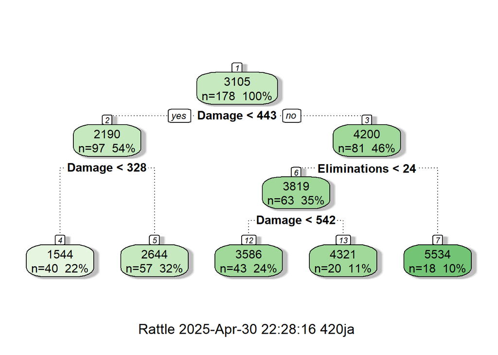

```r
fancyRpartPlot(RegTree, cex = 1)
```

```r
RegTree$variable.importance
```

```
##       Damage Eliminations      TotalXP       Deaths          Win       XPType
##    250835300    237532841     64376422     39929580     26429532     11012305
```

Based on the regression tree and using RegTree$variable.importance, we were able to get the values associated with each variable’s importance with the three highest variable importance values being `Damage` (250835300), `Eliminations` (237532841), and `TotalXP` (64376422).

## Task 2c. Standardized Model

```r
CODGames2_mp_HC_TDM_standardized <- CODGames2_mp_HC_TDM %>%
  mutate(XPType = ifelse(XPType == "Double XP + 10%", 1, 0),
         TotalXP = scale(TotalXP, center = TRUE, scale = TRUE),
         Eliminations = scale(Eliminations, center = TRUE, scale = TRUE),
         Deaths = scale(Deaths, center = TRUE, scale = TRUE),
         XPType = scale(XPType, center = TRUE, scale = TRUE),
         Win = scale(Win, center = TRUE, scale = TRUE)
         )

standardized_model <- lm(Score ~ TotalXP + Eliminations + Deaths + XPType + Win, data = CODGames2_mp_HC_TDM_standardized)
summary(standardized_model)
```

```
##
## Call:
## lm(formula = Score ~ TotalXP + Eliminations + Deaths + XPType +
##     Win, data = CODGames2_mp_HC_TDM_standardized)
##
## Residuals:
##      Min       1Q   Median       3Q      Max
## -2000.77  -444.28   -35.43   327.75  2912.93
##
## Coefficients:
##              Estimate Std. Error t value Pr(>|t|)
## (Intercept)   3104.95      52.87  58.733  < 2e-16 ***
## TotalXP        382.88      84.07   4.554 9.91e-06 ***
## Eliminations  1030.92      66.88  15.415  < 2e-16 ***
## Deaths        -276.49      57.11  -4.841 2.86e-06 ***
## XPType        -182.80      73.19  -2.498  0.01344 *
## Win           -226.12      57.75  -3.916  0.00013 ***
## ---
## Signif. codes:  0 '***' 0.001 '**' 0.01 '*' 0.05 '.' 0.1 ' ' 1
##
## Residual standard error: 705.3 on 172 degrees of freedom
## Multiple R-squared:  0.7697, Adjusted R-squared:  0.763
## F-statistic:   115 on 5 and 172 DF,  p-value: < 2.2e-16
```

Using the standardized model, it produced the estimated equation: `Score` = 3104.95 + 382.88`TotalXP` + 1030.92`Eliminations` - 276.49`Deaths` - 182.80`XPType` - 226.12`Win`. Based on the magnitude (absolute value) of the estimated coefficients, the three most important variables are `Eliminations` (1030.92), `TotalXP` (382.88), and `Deaths` (276.49).

# Contribution

Jackie Yang: Completed task1 and task2a and task2b and their comment

Xinyu Xie: Completed task2c with comments and fixing some problems